G34-gliomas project [[source](https://github.com/fungenomics/G34-gliomas)]

# 05 - Plot 4C contacts at GSX2 and PDGFRA

28 September, 2020

# 1 Configuration

Configuration of project directory & analysis outputs:

**Show full config**

```r
library(here)

# Set up outputs
message("Document index: ", doc_id)
```

```
## Document index: 05
```

```r
# Specify where to save outputs
out        <- here(subdir, "output", doc_id); dir.create(out, recursive = TRUE)
figout     <- here(subdir, "figures", doc_id, "/"); dir.create(figout, recursive = TRUE)
cache      <- paste0("~/tmp/", basename(here()), "/", subdir, "/", doc_id, "/")

message("Cache: ", cache)
```

```
## Cache: ~/tmp/G34-gliomas/bulk_transcriptome_epigenome/05/
```

The root directory of this project is:

```
## /lustre03/project/6004736/sjessa/from_beluga/HGG-G34/G34-gliomas
```

Outputs and figures will be saved at these paths, relative to project root:

```
## G34-gliomas/bulk_transcriptome_epigenome/output/05
```

```
## G34-gliomas/bulk_transcriptome_epigenome/figures/05//
```

Setting a random seed:

```r
set.seed(100)
```

# 2 Overview

In this document, we load a 4C quantification of the contacts between parts of the genome from Hi-C data in tumors and normal brain, focusing on contacts anchored at PDGFRA or GSX2.

# 3 Libraries

```r
library(readxl)
library(ggplot2)
library(cowplot)
library(tidyr)
library(dplyr)

# Theme
ggplot2::theme_set(theme_min(base_size = 13))

# Custom
source(here::here(subdir, "analysis/functions.R"))
```

# 4 Analysis

## 4.1 Anchored at PDGFRA

Generate the plots for contacts anchored at the PDGFRA promoter:

### 4.1.1 Human

```r
data <- read_excel(here(subdir, "data/PDGFRA_promoter_4C_human.xlsx"))

# Convert to long format so that we have three columns in the data frame:
# 1) Group (G34 or Other), 2) Average value, and 3) Standard deviation value
data_long <- data %>%
    unite(G34,   Average_G34_pGBMs,   stdeva_G34_pGBMs) %>%
    unite(Other, Average_Other_pGBMs, stdeva_other_pGBMs) %>%
    gather(Group, Value, G34, Other) %>%
    separate(Value, into = c("Average", "Stdev"), sep = "_")

# Convert the missing values around PDGFRA to 0
data_long$Average <- ifelse(data_long$Average == "NA", 0, data_long$Average)
data_long$Stdev   <- ifelse(is.na(data_long$Stdev),    0, data_long$Stdev)

# Make sure we have numeric columns for plotting
data_long$Average <- as.numeric(data_long$Average)
data_long$Stdev   <- as.numeric(data_long$Stdev)
```

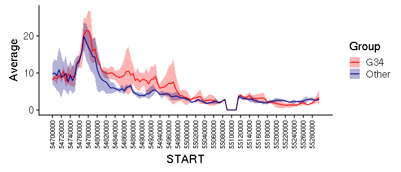

```r
# Colour palette
palette_human <- c("red", "navy")

# Write a plotting function
plot_4c <- function(df, palette) {

  df %>%
    rr_ggplot(aes(x = START, y = Average), plot_num = 1) +
    # Plot the stdev as an area "ribbon"
    geom_ribbon(aes(ymin = Average - Stdev, ymax = Average + Stdev, fill = Group), alpha = 0.3) +
    # Plot the solid line for the average
    geom_line(aes(colour = Group)) +
    # Set the colours
    scale_colour_manual(values = palette) +
    scale_fill_manual(values = palette) +
    # Add more breaks to the x-axis
    scale_x_continuous(breaks = seq(from = min(data$START), to = max(data$START), by = 20000)) +
    theme_cowplot() +
    theme(axis.text.x = element_text(angle = 90, vjust = 0.5, hjust = 1, size = rel(0.7)))

}

plot_4c(data_long, palette_human)
```

<sub>[figure/source data @ *G34-gliomas/bulk_transcriptome_epigenome/figures/05//human_pdgfra_plot…*]</sub>

### 4.1.2 Mouse

```r
data <- read_excel(here(subdir, "data/PDGFRA_promoter_4C_mice.xlsx"))

# Convert to long format so that we have three columns in the data frame:
# 1) Group (G34 or Other), 2) Average value, and 3) Standard deviation value
data_long <- data %>%
  unite(GE,     Average_GE, STDEVA_GE) %>%
  unite(Cortex, Average_Cortex, STDEVA_Cortex) %>%
  unite(ESC,    Average_ESC, STDEVA_ESC) %>%
  gather(Group, Value, GE, Cortex, ESC) %>%
  separate(Value, into = c("Average", "Stdev"), sep = "_")

# Make sure we have numeric columns for plotting
data_long$Average <- as.numeric(data_long$Average)
data_long$Stdev   <- as.numeric(data_long$Stdev)
```

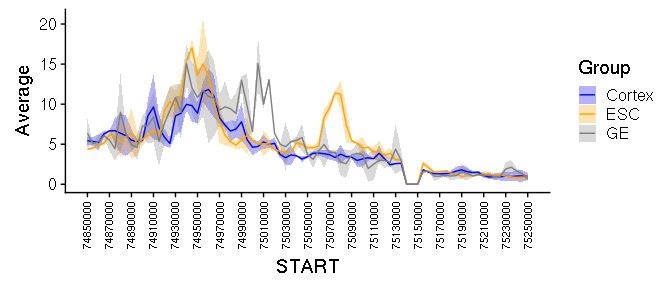

```r
# Colour palette
palette_mouse <- c("blue", "orange", "gray50")

# Plot
plot_4c(data_long, palette_mouse)
```

<sub>[figure/source data @ *G34-gliomas/bulk_transcriptome_epigenome/figures/05//mouse_pdgfra_plot…*]</sub>

## 4.2 Anchored at GSX2

Generate the plots for contacts anchored at the GSX2 promoter:

### 4.2.1 Human

```r
data <- read_excel(here(subdir, "data/GSX2_promoter_4C_human.xlsx"))

# Convert to long format so that we have three columns in the data frame:
# 1) Group (G34 or Other), 2) Average value, and 3) Standard deviation value
data_long <- data %>%
    unite(G34,   Average_G34, STDEVA_G34) %>%
    unite(Other, Average_other_pGBMs, STDEVA_non_G34) %>%
    gather(Group, Value, G34, Other) %>%
    separate(Value, into = c("Average", "Stdev"), sep = "_")

# Make sure we have numeric columns for plotting
data_long$Average <- as.numeric(data_long$Average)
data_long$Stdev   <- as.numeric(data_long$Stdev)
```

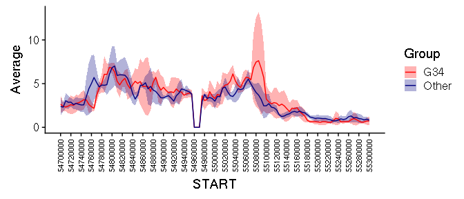

```r
plot_4c(data_long, palette_human)
```

<sub>[figure/source data @ *G34-gliomas/bulk_transcriptome_epigenome/figures/05//human_gsx2_plot…*]</sub>

### 4.2.2 Mouse

```r
data <- read_excel(here(subdir, "data/GSX2_promoter_4C_mice.xlsx"))

# Convert to long format so that we have three columns in the data frame:
# 1) Group (G34 or Other), 2) Average value, and 3) Standard deviation value
data_long <- data %>%
  unite(GE,     Average_GE, STDEVA_GE) %>%
  unite(Cortex, Average_Cortex, STDEVA_Cortex) %>%
  unite(ESC,    Average_ESC, STDEVA_ESC) %>%
  gather(Group, Value, GE, Cortex, ESC) %>%
  separate(Value, into = c("Average", "Stdev"), sep = "_") %>%
  filter(Group != "ESC")

# Make sure we have numeric columns for plotting
data_long$Average <- as.numeric(data_long$Average)
data_long$Stdev   <- as.numeric(data_long$Stdev)
```

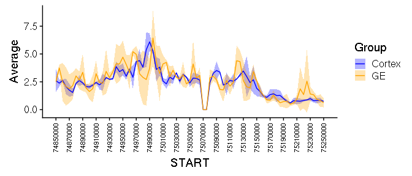

```r
plot_4c(data_long, palette_mouse)
```

<sub>[figure/source data @ *G34-gliomas/bulk_transcriptome_epigenome/figures/05//mouse_gsx2_plot…*]</sub>

# 5 Reproducibility

This document was last rendered on:

```
## 2020-09-28 09:59:15
```

The git repository and last commit:

```
## Local:    master /lustre03/project/6004736/sjessa/from_beluga/HGG-G34/G34-gliomas
## Remote:   master @ origin (git@github.com:fungenomics/G34-gliomas.git)
## Head:     [f55adef] 2020-09-25: Add PDGFRA-GSX2 correlation for non-G34 samples
```

The random seed was set with `set.seed(100)`

A project of the Kleinman Lab at McGill University, using the [rr](https://github.com/sjessa/rr/) reproducible research template.  
[home](https://functionalgenomics.ca/) [GitHub](https://github.com/fungenomics/)